# IE582 HW-1

## IE582 HW-1

## Task 1-1

At first, I installed data.table, got the data and filter it to English Premier Lig.

```r
library(data.table)
matches<-read.csv("C:/Users/gÜlce/Desktop/4-1/582/hw1/data/matches.csv")
English_Premier_League_matches<-matches[matches[["league_id"]] == "148", ]
```

## Home Score:

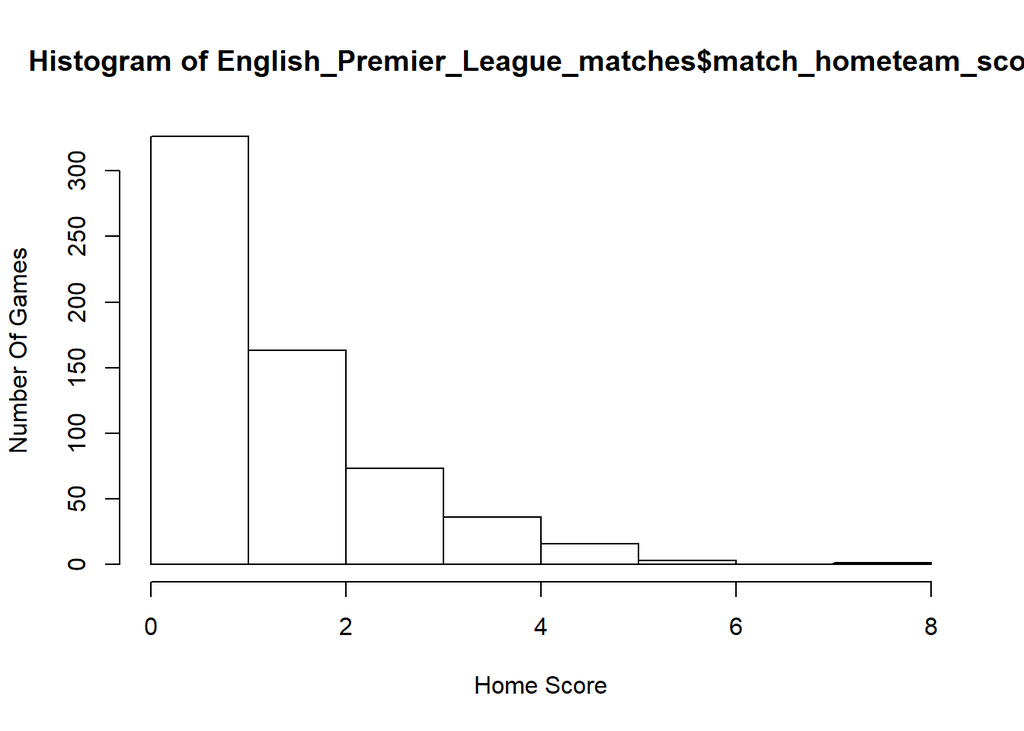

```r
hist(English_Premier_League_matches$match_hometeam_score,xlab="Home Score",ylab="Number Of Games")
```

## Away Score:

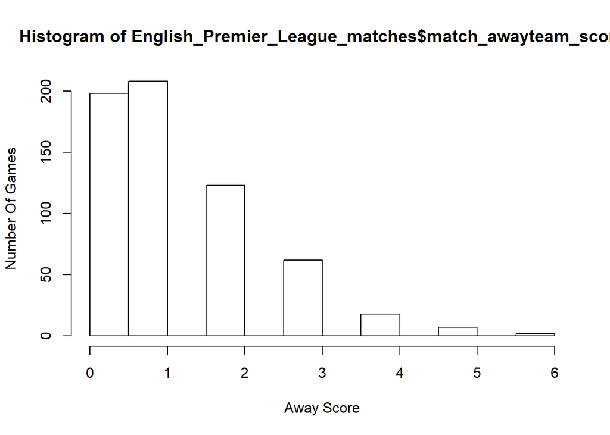

```r
hist(English_Premier_League_matches$match_awayteam_score,xlab="Away Score",ylab="Number Of Games")
```

## Home Score-Away_Score:

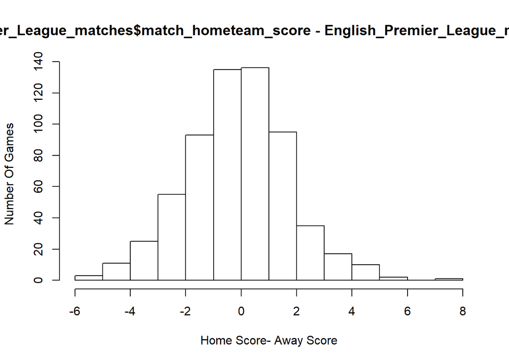

```r
hist(English_Premier_League_matches$match_hometeam_score-English_Premier_League_matches$match_awayteam_score, xlab="Home Score- Away Score",ylab="Number Of Games")
```

## Task 1-2

I calculated sample mean of home team scores in English Premier League.Then,I found intervals for Poisson distribution and used sample mean as mean of the distribution. I made histogram of the distribution and compare it with plotted theoretical distribution.It fitted on poisson distribution.

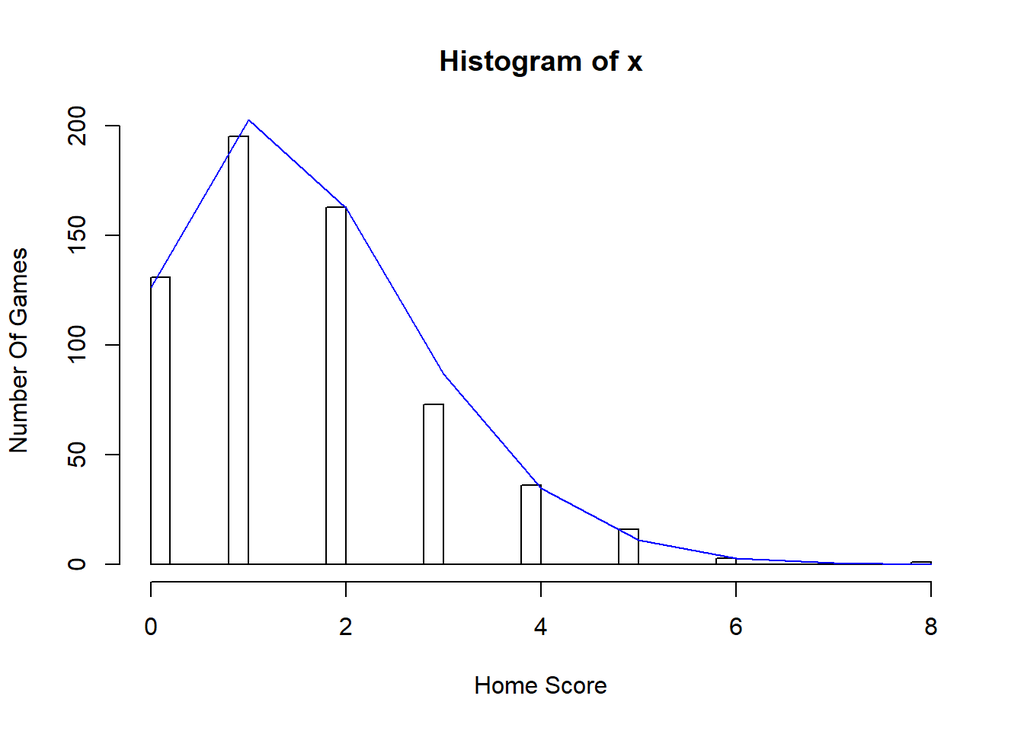

```r
mean_hometeam_score<-mean(English_Premier_League_matches$match_hometeam_score,na.rm=T)

max<-max(English_Premier_League_matches$match_hometeam_score,na.rm=T)
min<-min(English_Premier_League_matches$match_hometeam_score,na.rm=T)

x<-English_Premier_League_matches$match_hometeam_score
h<-hist(x,breaks=50, xlab="Home Score",ylab="Number Of Games")

xfit<-seq(min,max,length=9)
yfit<-dpois(xfit,mean_hometeam_score)
yfit <- yfit*length(x)
lines(xfit, yfit, col="blue")
```

I did the same procedure for away team scores in English Premier League.It fitted on poisson distribution.

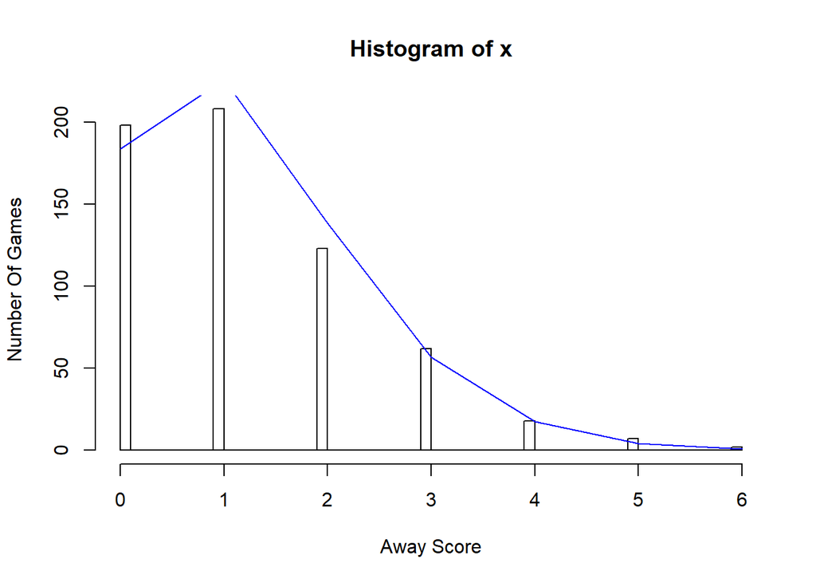

```r
mean_awayteam_score<-mean(English_Premier_League_matches$match_awayteam_score,na.rm=T)

max<-max(English_Premier_League_matches$match_awayteam_score,na.rm=T)
min<-min(English_Premier_League_matches$match_awayteam_score,na.rm=T)

x<-English_Premier_League_matches$match_awayteam_score
h<-hist(x,breaks=50, xlab="Away Score",ylab="Number Of Games")

xfit<-seq(min,max,length=7)
yfit<-dpois(xfit,mean_awayteam_score)
yfit <- yfit*length(x)
lines(xfit, yfit, col="blue")
```

I did the same procedure for (home team-away team) scores in English Premier League. It did not fit on poisson distribution but fitted on normal distribution.

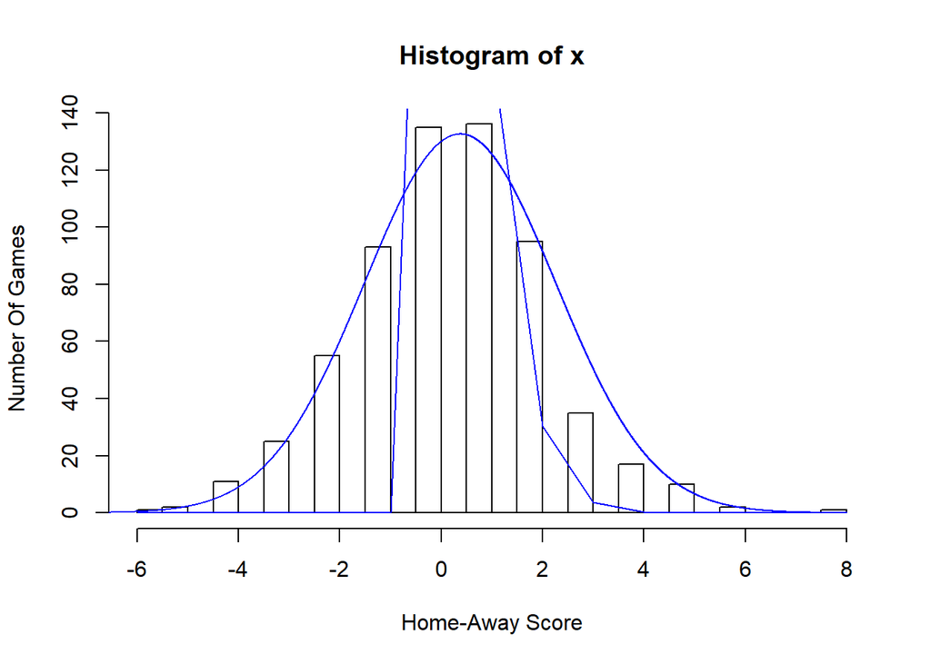

```r
mean_home_minus_away_score<-mean(English_Premier_League_matches$match_hometeam_score-English_Premier_League_matches$match_awayteam_score,na.rm=T)

max<-max(English_Premier_League_matches$match_hometeam_score-English_Premier_League_matches$match_awayteam_score,na.rm=T)
min<-min(English_Premier_League_matches$match_hometeam_score-English_Premier_League_matches$match_awayteam_score,na.rm=T)
x<-English_Premier_League_matches$match_hometeam_score-English_Premier_League_matches$match_awayteam_score
h<-hist(x,breaks=50, xlab="Home-Away Score",ylab="Number Of Games")

xfit<-seq(min,max,length=15)
yfit<-dpois(xfit,mean_home_minus_away_score)
yfit <- yfit*length(x)
lines(xfit, yfit, col="blue")

xfit<-seq(-8,8,length=10000)
y<-dnorm(xfit, mean = mean_home_minus_away_score, sd = sd(x, na.rm = T), log = FALSE)
yfit<-y*length(x)
lines(xfit,yfit,col="blue")
```

## Task 2-1

First, I turned csv to data.table.Then I selected bookmakers: BetOlimp, 10Bet, 18bet, 1xBet.

```r
betsdata<-fread("C:/Users/gÜlce/Desktop/4-1/582/hw1/data/bets.csv")
bets_of_chosen_bookmakers<-betsdata[betsdata$"odd_bookmakers" %in% c("BetOlimp" , "10Bet" , "18bet" , "1xBet") ]
```

I calculated probabilities for home win, tie and away win.

```r
bets_for_homewin<-bets_of_chosen_bookmakers[bets_of_chosen_bookmakers[["variable"]] == "odd_1" ]

odds_of_homewin<-bets_for_homewin$value
odd_prob_of_homewin<-1/odds_of_homewin


bets_for_draw<-bets_of_chosen_bookmakers[bets_of_chosen_bookmakers[["variable"]] == "odd_x" ]

odds_of_draw<-bets_for_draw$value
odd_prob_of_draw<-1/odds_of_draw


bets_for_away<-bets_of_chosen_bookmakers[bets_of_chosen_bookmakers[["variable"]] == "odd_2" ]

odds_of_away<-bets_for_away$value
odd_prob_of_away<-1/odds_of_away
```

## Task 2-2

I normalized probabilites.

```r
normalizationterm<-1/(odd_prob_of_homewin + odd_prob_of_draw + odd_prob_of_away  )

norm_odd_prob_of_homewin<-odd_prob_of_homewin*normalizationterm

norm_odd_prob_of_draw<-odd_prob_of_draw*normalizationterm

norm_odd_prob_of_away<-odd_prob_of_away*normalizationterm
```

## Task 2-3

Plotted with the first probabilities and then with actual probabilities.

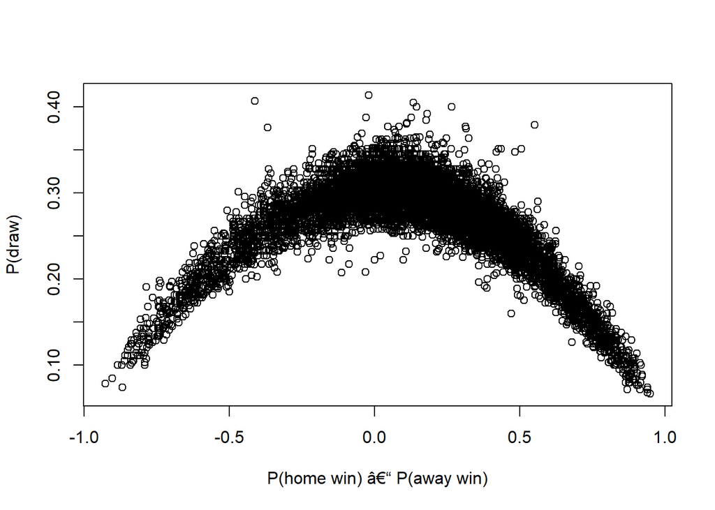

```r
plot(odd_prob_of_homewin-odd_prob_of_away , odd_prob_of_draw,xlab = "P(home win) â€“ P(away win)" , ylab="P(draw)" )
```

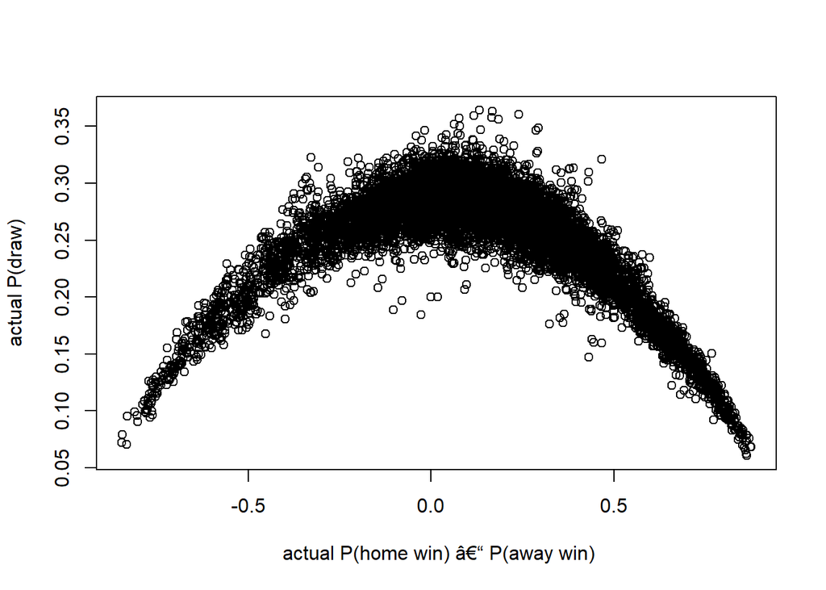

```r
plot(norm_odd_prob_of_homewin-norm_odd_prob_of_away , norm_odd_prob_of_draw, xlab = " actual P(home win) â€“ P(away win)" , ylab="actual P(draw)")
```

## Task 2-4

Installed tidyverse, got matches as datatable and then created new column to detect “draw” situations.

```r
library(tidyverse)
matchesdatatable<-fread("C:/Users/gÜlce/Desktop/4-1/582/hw1/data/matches.csv")
matchesdatatable[,Home_minus_away_column:=match_hometeam_score-match_awayteam_score]
```

Prepared bets data in order to observe just odd_1,odd_x and odd_2 variables, made long to wide.

```r
bets_of_chosen_bookmakers<-bets_of_chosen_bookmakers[variable == "odd_1" | variable == "odd_x" | variable == "odd_2"] %>%
  spread(variable,value)
```

Created new columns to get P(home)-P(away)

```r
bets_of_chosen_bookmakers[,Phome:=norm_odd_prob_of_homewin]
```

```r
bets_of_chosen_bookmakers[,Pdraw:=norm_odd_prob_of_draw]
bets_of_chosen_bookmakers[ ,Paway:=norm_odd_prob_of_away]
bets_of_chosen_bookmakers[ ,Phomeaway:=Phome-Paway]
```

Separated four bookmakers.

```r
bets_of_chosen_bookmakers_BetOlimp<-bets_of_chosen_bookmakers[bets_of_chosen_bookmakers$"odd_bookmakers" %in% c("BetOlimp")]
bets_of_chosen_bookmakers_10Bet<-bets_of_chosen_bookmakers[bets_of_chosen_bookmakers$"odd_bookmakers" %in% c("10Bet")]
bets_of_chosen_bookmakers_18bet<-bets_of_chosen_bookmakers[bets_of_chosen_bookmakers$"odd_bookmakers" %in% c("18bet")]
bets_of_chosen_bookmakers_1xBet<-bets_of_chosen_bookmakers[bets_of_chosen_bookmakers$"odd_bookmakers" %in% c("1xBet")]
```

Discretized into bins for each bookmakers.

```r
cutted_BetOlimp<-cut(bets_of_chosen_bookmakers_BetOlimp$Phomeaway, breaks=c(-1,-0.8,-0.6,-0.4,-0.2,0,0.2,0.4,0.6,0.8,1), include.lowest=TRUE , labels = c("bin1" , "bin2","bin3","bin4","bin5","bin6","bin7","bin8","bin9","bin10" ))
bets_of_chosen_bookmakers_BetOlimp[ ,bin:=cutted_BetOlimp]

cutted_10Bet<-cut(bets_of_chosen_bookmakers_10Bet$Phomeaway, breaks=c(-1,-0.8,-0.6,-0.4,-0.2,0,0.2,0.4,0.6,0.8,1), include.lowest=TRUE , labels = c("bin1" , "bin2","bin3","bin4","bin5","bin6","bin7","bin8","bin9","bin10" ))
bets_of_chosen_bookmakers_10Bet[ ,bin:=cutted_10Bet]

cutted_18bet<-cut(bets_of_chosen_bookmakers_18bet$Phomeaway, breaks=c(-1,-0.8,-0.6,-0.4,-0.2,0,0.2,0.4,0.6,0.8,1), include.lowest=TRUE , labels = c("bin1" , "bin2","bin3","bin4","bin5","bin6","bin7","bin8","bin9","bin10" ))
bets_of_chosen_bookmakers_18bet[ ,bin:=cutted_18bet]

cutted_1xBet<-cut(bets_of_chosen_bookmakers_1xBet$Phomeaway, breaks=c(-1,-0.8,-0.6,-0.4,-0.2,0,0.2,0.4,0.6,0.8,1), include.lowest=TRUE , labels = c("bin1" , "bin2","bin3","bin4","bin5","bin6","bin7","bin8","bin9","bin10" ))
bets_of_chosen_bookmakers_1xBet[ ,bin:=cutted_1xBet]
```

“Draw” matches matched with bins according to match_id.